# How TIFs Impact Tax Bills

Eric Langowski

Tax increment financing (TIF) is a “special funding tool…used to promote public and private investment” in specific areas. TIFs are funded by capturing future property value increases through freezing property values for 23 or 35 years.

In practice, TIFs have strange impacts on the property tax system. For example, any appeals or exemptions granted to properties in a TIF which is above its initial frozen value have no impact on tax rates and **only** reduce the amount of revenue that a TIF collects. This analysis presents a simplified analysis which explores how appeals or decreases in assessed value impact tax bills.

# Central Business District

A [recent article](https://wirepoints.org/chicagos-commercial-doom-loop-could-result-in-a-property-tax-hike-on-homeowners-as-large-as-22-wirepoints/) estimated changes in Chicago tax bills if there was a 50% decrease in downtown commercial property values. They estimated that this would lead to a 22% increase in values, but taking into account that many commercial downtown properties are in TIFs the change in median Chicago residential tax bills is about 13.5%. This is since reductions in equalized assessed value (eav) for TIFs which are above their frozen eavs lead to a reduction only in TIF revenue with no impact on the larger tax base.

For the purposes of this analysis, the CBD commercial properties are considered class 500 through 899 located in West, North, or South Chicago townships.

## Tax Bill Simulation

In order to illustrate how reductions in CBD Commercial EAV would impact residential tax bills across Chicago, all tax bills in Chicago were simulated 101 times at different percent reductions in CBD EAV (e.g. 0% reduction, 1% reduction, …, 100% reduction). These simulations are then presented in the following graphs where the x-axis represents the simulated percent reduction in CBD commerical EAV.

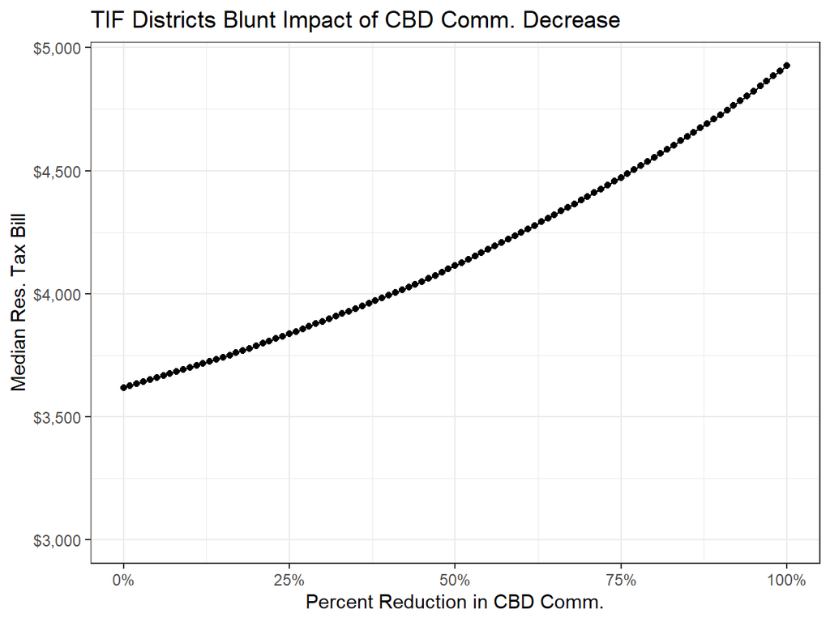

Above is shown the change in median residential tax bill against a simulated percent reduction in central business district (CBD) commercial properties. For example, a 50% decrease in eav for CBD commercial properties corresponds with a median residential bill of $4,114.

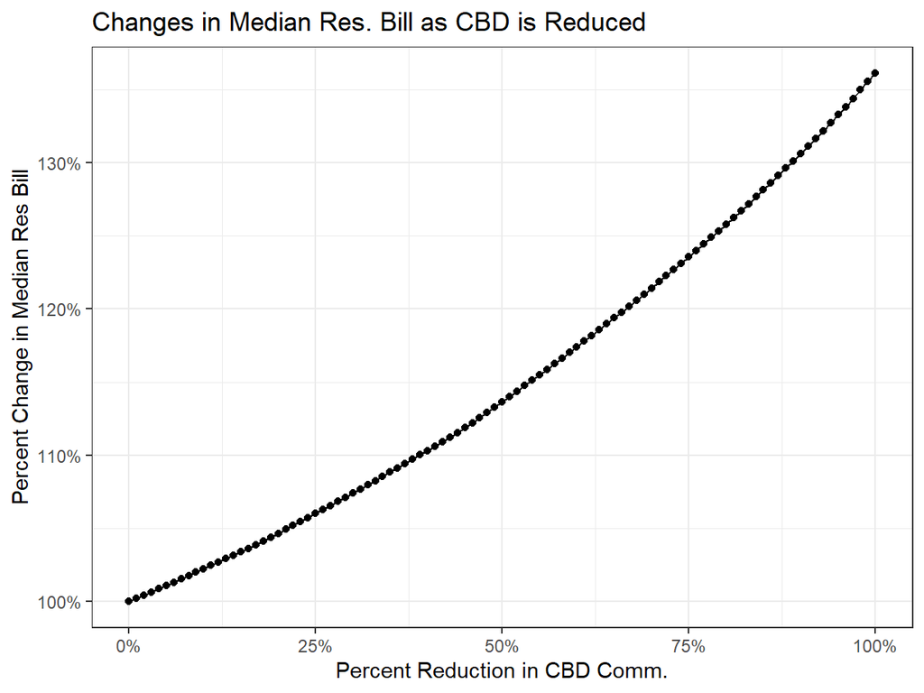

Above is shown the percentage increase in median residential bill for simulated percentage reductions in CBD commercial eav. For example, a 50% decrease in CBD eav corresponds with an approximate 13% increase in median residential bills.

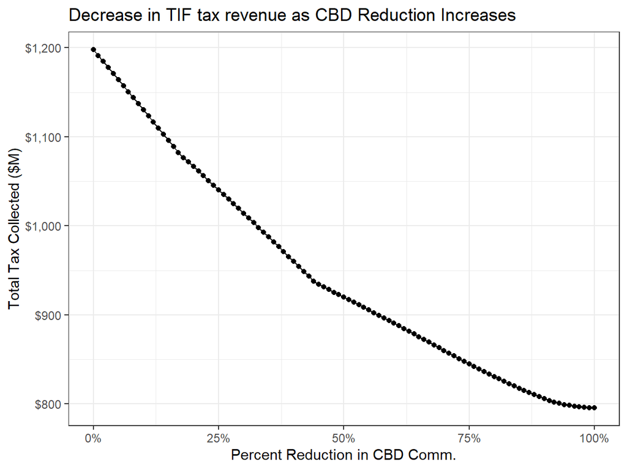

Above is shown the decrease in total revenue collected by Chicago TIF districts against simulated decreases in CBD commercial EAV. For example, a 100% reduction in CBD commercial EAV leads for TIF revenue to fall from 1.2 billion to 800 million dollars.

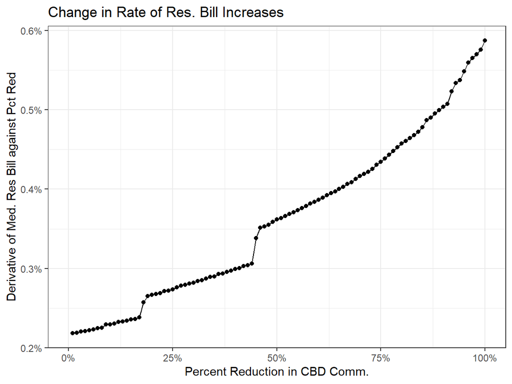

This graph shows the rate at which residential bills increase for every 1% decrease in CBD eav. For example, from a 99% reduction to a 100% reduction in EAV, median residential bills increase 0.6%.

# ‘Free’ Appeals

Whenever a property makes a successful appeal (which is not in a TIF), it reduces its individual EAV and the total amount of EAV available to its taxing districts. This causes an increase in tax rates for its taxing bodies. If a property is in a TIF and that TIF is above its frozen EAV, an appeal will be ‘free’ to its taxing bodies lowering only the amount of EAV that the TIF collects tax revenue on. Appeals have many impacts in Cook County and this section presents a narrow analysis focused only on TIF districts.

## Appeals Summary

The impact of successful appeals can be measured from mailed assessor values to certified assessor values (“Assessor appeals”) and from certified assessor values to final board of review values (“Board appeals”).

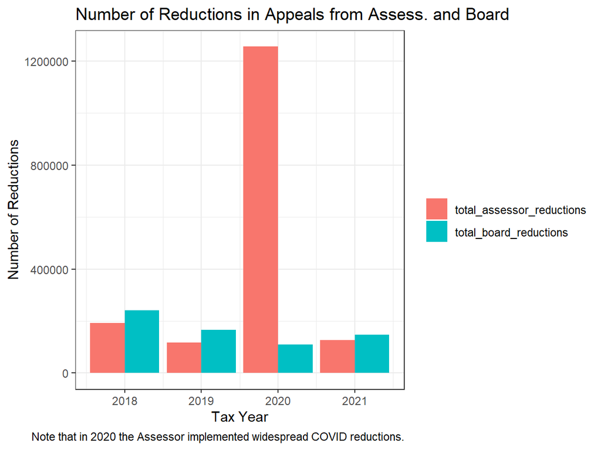

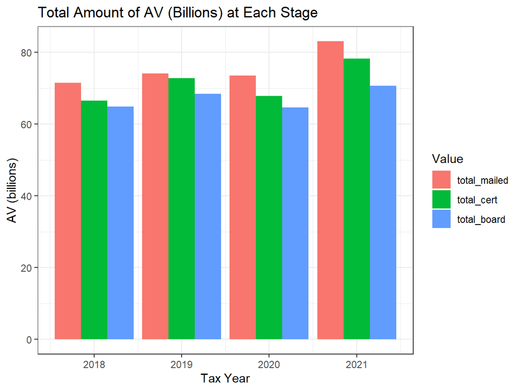

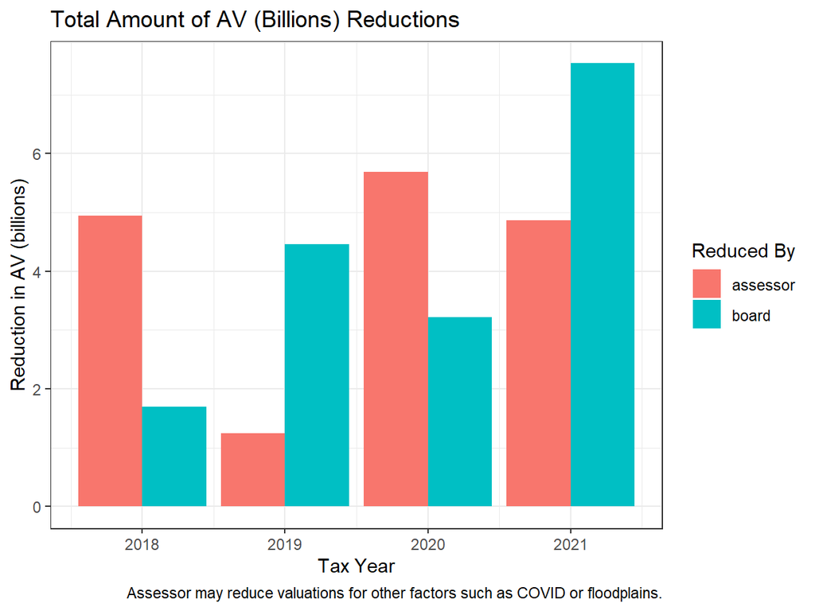

In 2021 for example, the total amount of AV fell from 83.1 billion (mailed) to 78.2 billion (certified) to 70.7 billion (board).

## Appeals in TIF Districts

This analysis was conducting by calculating the change in EAV by tax code throughout the appeal process, aligning those tax codes summations with TIF districts, and identifying when appeals were made above or below the TIF cap. Here the ‘capped’ change in EAV across Assessor and Board appeals is calculated. Note that the Assessor may sometimes lower values due to other factors such as floodplains (2018) or COVID-19 (2020).

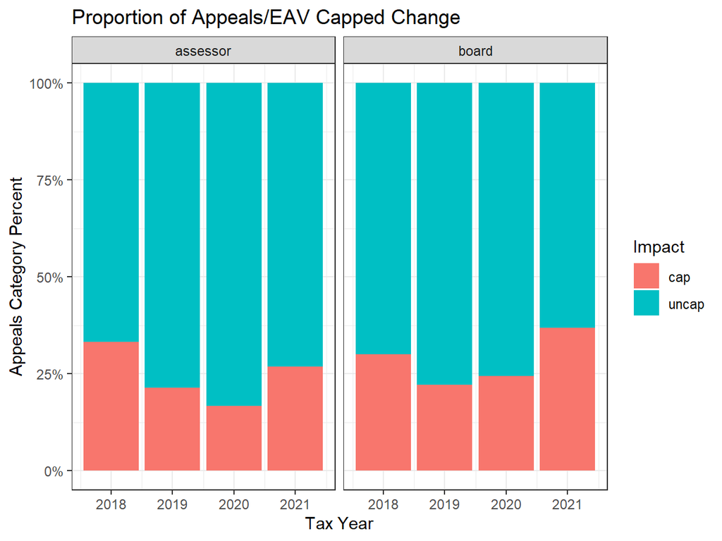

Each bar shows the proportions of appeals at the Assessor and Board level which were either capped (e.g. within a TIF above the TIF’s frozen EAV amount) or uncapped. Capped appeals will have no impact on the total EAV available to taxing bodies and therefore will result in no change in tax rates or tax bills. In 2021, for example, about 37% of the total EAV amount granted in appeals at the Board was capped and therefore had no impact on tax rates.

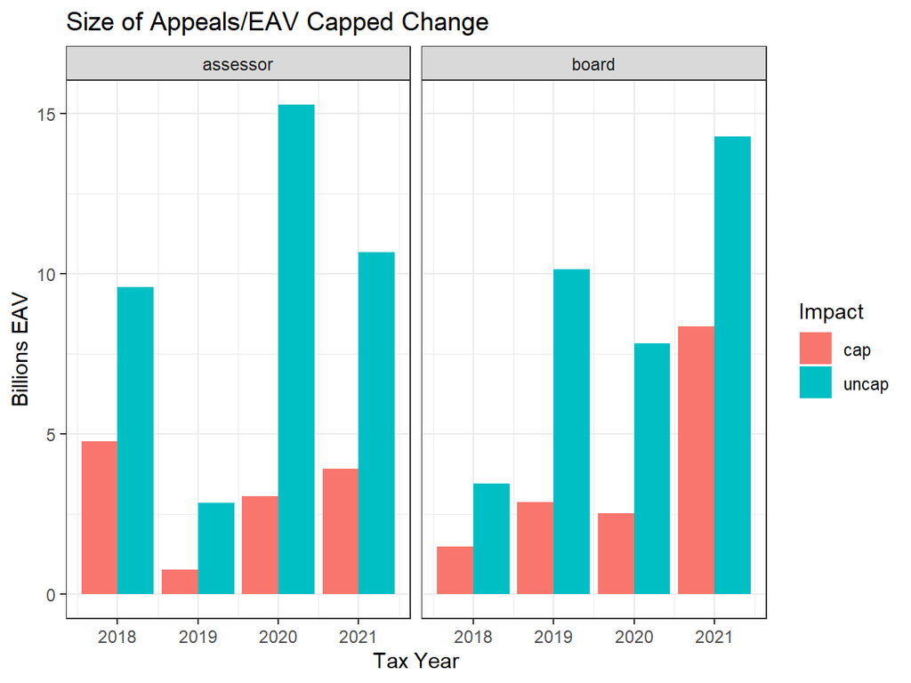

Here the absolute amount in Billions of EAV of appeals granted is shown and their impact on the tax base.

# Notes

This analysis utilizes [PTAXSIM](https://ccao-data-science---modeling.gitlab.io/packages/ptaxsim/index.html) and Cook County Open Data. In particular, the analysis of [Tinkering with TIFs](https://ccao-data-science---modeling.gitlab.io/packages/ptaxsim/articles/tifs.html) is replicated and expanded here with great thanks to the Cook County Assessor’s Office Data Science team for assistance debugging.